## Homework 1

*Enter your name and EID here*

**This homework is due on Jan. 26, 2016 at 11:59pm. Please submit as a pdf file on Canvas.**

This homework uses the `chickwts` data set available in R. This data set contains the weight of chicks (`weight`) after being fed different feed supplements (`feed`). There are six different types of feed supplements observed in the data set (labeled casein, horsebean, linseed, meatmeal, soybean, sunflower), each with 10–14 observations.

```r
head(chickwts)
```

```
##   weight      feed
## 1    179 horsebean
## 2    160 horsebean
## 3    136 horsebean
## 4    227 horsebean
## 5    217 horsebean
## 6    168 horsebean
```

**Problem 1: (4 pts)** We are interested in testing the effectiveness of various feed supplements on the growth rate of chickens. Since there are six different types of supplements in the data set, and therefore six groups of weight measurements, we will use an analysis of variance (ANOVA) test. Conduct an ANOVA test and interpret your results in 1-2 sentences. HINT: You will first need to create a linear model object using the `lm()` function before you can use the `anova()` function.

```r
chicks.mod <- lm(weight ~ feed, data = chickwts)
anova(chicks.mod)
```

```
## Analysis of Variance Table
##
## Response: weight
##           Df Sum Sq Mean Sq F value    Pr(>F)
## feed       5 231129   46226  15.365 5.936e-10 ***
## Residuals 65 195556    3009
## ---
## Signif. codes:  0 '***' 0.001 '**' 0.01 '*' 0.05 '.' 0.1 ' ' 1
```

The weight means under each type of supplement are not equal, i.e., at least one supplement type must be more effective than the others at increasing growth rate of chickens.

**Problem 2: (3 pts)** Create a boxplot of the chick weights, separated by feed supplement type. Based on this plot, is the mean weight of horsebean the same or different from that of sunflower? Explain your answer.

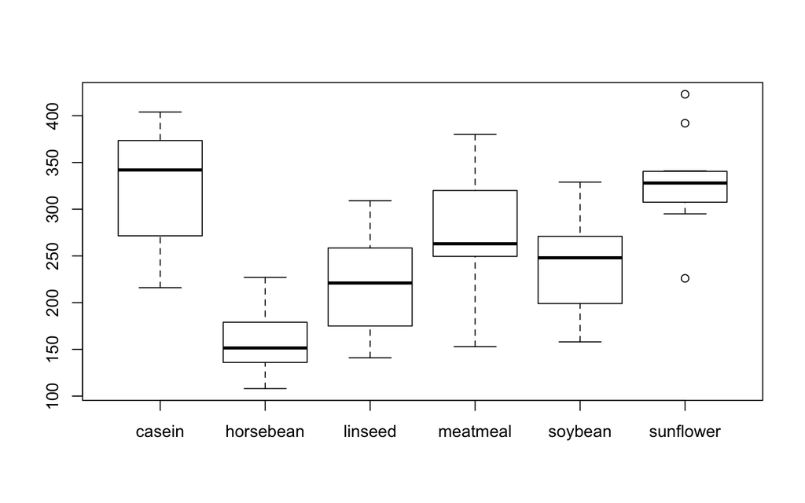

```r
boxplot(weight ~ feed, data = chickwts)
```

With one exception, the weights under horsebean are all lower than the lowest weight under sunflower. Thus, we expect that the means will be different.

**Problem 3: (3 pts)** Use a t test to determine if the mean weight of horsebean is the same or different from that of sunflower. Interperet and explain your results in 1-2 sentences.

```r
t.test(chickwts$weight[chickwts$feed == 'horsebean'], chickwts$weight[chickwts$feed == 'sunflower'])
```

```
##
##  Welch Two Sample t-test
##
## data:  chickwts$weight[chickwts$feed == "horsebean"] and chickwts$weight[chickwts$feed == "sunflower"]
## t = -9.0449, df = 19.964, p-value = 1.69e-08
## alternative hypothesis: true difference in means is not equal to 0
## 95 percent confidence interval:
##  -207.6313 -129.8021
## sample estimates:
## mean of x mean of y
##  160.2000  328.9167
```

The mean weight under horsebean is significantly smaller than under sunflower, i.e., sunflower is a more effective supplement.